# Class 6: Poissin/NegBin regression

Kim Johnson

February 20, 2019

# Lecture Outline

1. Count data
2. The Poisson distribution
3. The Poisson regression model
4. The negative binomial regression model
5. Comparisons between Poissin and negbin
6. Interpretations

# Learning Objectives

1. Be able to understand when to use Poisson or negative binomial regression
2. Understand how to run these models in R
3. Know how to interpet model results

# Count data

- The outcome variable is a count or the number of times an event has happened
- Examples:
  - Number of times using a service (visiting a doctor, hospitalization)
  - Daily homicides
  - Number of beverages consumed
  - Number of police arrests
  - Cancer rates
  - Car accidents
  - Genetic mutations
  - Birth defects
- The primary feature of a count variable is that it has a skewed distribution (as compared to a normal distritubtion)

# Ordinary least squares (i.e. linear regression)

- Cannot apply OLS to a count variable because it violates the normality assumption
- Models that deal with count outcomes:
1. The Poisson regression model: the probability of a count is determined by the Poisson distribution. The model has a defining characteristic that the conditional mean of the outcome is equal to the conditional variance.
2. The negative binomal regression model is needed when the conditional variance exceeds the conditional mean.
3. Other models for other violations (not considered here): zero-truncated models, hurdle regression models, zero-inflated models.

# The Poisson distribution

- The probability distribution of a Poisson random variable y (e.g. car accidents), which is the number of successes in a given interval of time or space is given by the below formula

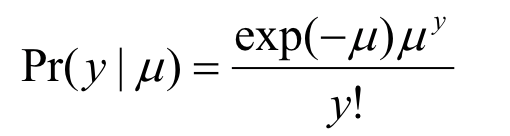

where y= 0,1, 2, …  
$\mu$ is the mean number of successes in a given time interval or region of space  
- The probability of y is a function of $\mu$:  
Pr(y=0|$\mu$) = exp(-$\mu$)  
Pr(y=1|$\mu$) = exp(-$\mu$)$\mu$  
Pr(y=3|$\mu$) = exp(-$\mu$)$\mu$<sup>3</sup>/6

# The Poisson distribution

# The Poisson distribution

- The variance equals the mean: Var(y)=E(y)=$\mu$
- This is a unique feature of the Poisson distribution known as **equidispersion**
- When the variance of the count is greater than the mean of the count in the sample, we say that the count variable y has **overdispersion**
- When overdisperison occurs, you should use the negative binomial model (or one of the other models noted above)

# The Poisson distribution

- As $\mu$ increases, the probability of 0’s decrease. i.e. the Pr(y=0) decreases
- As $\mu$ increases, the Poisson distribution approximates a normal distribution. When E($\mu$)=Var($\mu$)=10.5 for this dataset, a normal distribution superimposes on the Poisson distribution

# The Poisson distribution

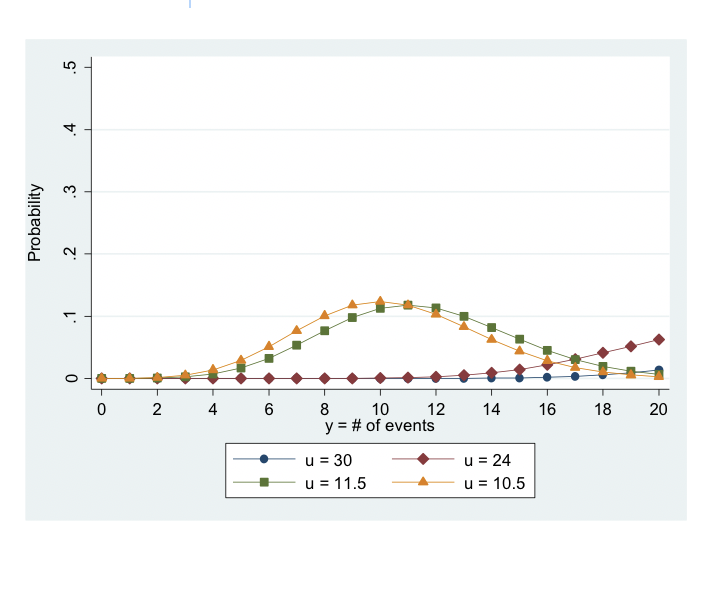

# Heterogeneity

- The key idea of statistical modeling is to use *independent variables* to model heterogeneity. When enough observed heterogeneities are accounted for, the model would fit the study data to a desirable degree.
- In Poisson regression, this task is known as finding important predictors of the rate of change $\mu$ (or the expected count).
- In a Poisson model with no predictors, the model often fails to account for heterogeneity, and the model predicted outcomes are largely different from the observed outcomes.
- Failure to account for heterogeneity also leads to overdispersion. When important predictors are used but one still encounters overdispersion, you need to employ negative binomial regression.

# The link function for Poisson

- Take a logarithm transformation of $\mu$
- The logarithm of the mean count is modeled as a linear combination of the unknown paremeters (the betas that are estimated by MLE)

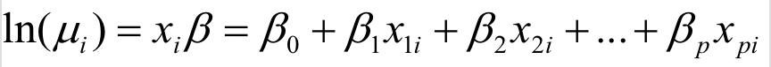

# Poisson model specification

- In R glm, we need to use the link function
- For specifying the model in reports, you can use the below equation

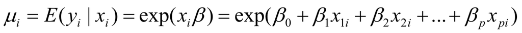

- The below formula will give you the predicted probability

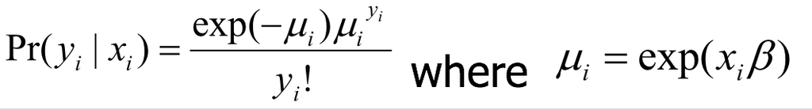

# Poisson regression output

- In Poisson regression, you get incidence rate ratios
- Incidence rate ratios are calculated as exp($\beta$)
- Betas (the model parameters) are estimated through maximimum liklihood
- Maximum liklihood finds the betas that result in the mean y that best fits the data

# Interpretation

- For a unit change in x, the expected count/incidence rate changes by a factor of exp($\beta$), other things being equal
- You can also interpet the change in terms of percentage change
- You can also use predicted probabilities to present and interpret findings (average marginal effects, marginal effects at means, and marginal effects at representative values); however, these are not commonly used in public health

# The negative binomial regression model

- The assumption that the conditional variance = the conditional mean in Poisson rarely holds. There is often overdispersion. In this scenario the negative binomial (negbin) can be used.
- To address the problem of overdispersion, the negbin model adds a parameter (so called overdispersion parameter $\alpha$) that allows the conditional variance of y to exceed the conditional mean.
- Overdispersion is when the observed variance in the response y is higher than the variance in the response y from the theoretical model. The consequence of this is that the estimated standard errors will be wrong (biased low) and the p-values will be too low.
- The motivation of adding this parameter is to model unobserved heterogeneity. In the negbin model, the mean $\mu$ is replaced with the random variable $\tilde{\mu}$

# The negative binomial model specification

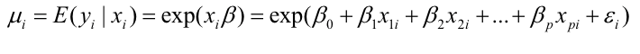

- You can calculate model predicted probabilities with the below formula:

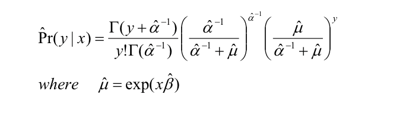

# Robust standard errors

# Comparisons between Poisson and negbin

# Interpretations of negbin

- Use either exp(B) or model-predicted probabilities to interpret findings of the negbin regression
- The exp(B) in the negbin regression has exactly the same meaning as that from a Poisson regression. It’s the “incidence-rate ratio”, or IRR.
- For a unit change in x, the expected count changes by a factor of exp(βx), other things being equal
- You can also interpret the change in terms of percentage change.
- Or you can use predicted probabilities but as said for Poisson, these are not commonly used in public health so we will not cover these here

# A last word–using offsets

- Sometimes our unit of observation for Poisson/negbin is at the group level rather than the individual level (counts/group number rather than counts/individual number)
- In this case we need an extra term in our model on the right hand side that is the log of the population or person years at risk.

# Skin cancer example (Applied Regression Analysis and Multivariable Methods, 4th Edition. and https://rpubs.com/kaz_yos/poisson)’

# Create a function to calculate IRR

```r
glm.RR <- function(GLM.RESULT, digits = 2) {

    if (GLM.RESULT$family$family == "binomial") {
        LABEL <- "OR"
    } else if (GLM.RESULT$family$family == "poisson") {
        LABEL <- "RR"
    } else {
        stop("Not logistic or Poisson model")
    }

    COEF      <- stats::coef(GLM.RESULT)
    CONFINT   <- stats::confint(GLM.RESULT)
    TABLE     <- cbind(coef=COEF, CONFINT)
    TABLE.EXP <- round(exp(TABLE), digits)

    colnames(TABLE.EXP)[1] <- LABEL

    TABLE.EXP
}
```

# Skin cancer data

```r
## Create a dataset manually
nonmel <- read.table(header = TRUE,
                     text = "
   cases city u1 u2 u3 u4 u5 u6 u7      n
1      1    0  1  0  0  0  0  0  0 172675
2     16    0  0  1  0  0  0  0  0 123065
3     30    0  0  0  1  0  0  0  0  96216
4     71    0  0  0  0  1  0  0  0  92051
5    102    0  0  0  0  0  1  0  0  72159
6    130    0  0  0  0  0  0  1  0  54722
7    133    0  0  0  0  0  0  0  1  32185
8     40    0  0  0  0  0  0  0  0   8328
9      4    1  1  0  0  0  0  0  0 181343
10    38    1  0  1  0  0  0  0  0 146207
11   119    1  0  0  1  0  0  0  0 121374
12   221    1  0  0  0  1  0  0  0 111353
13   259    1  0  0  0  0  1  0  0  83004
14   310    1  0  0  0  0  0  1  0  55932
15   226    1  0  0  0  0  0  0  1  29007
16    65    1  0  0  0  0  0  0  0   7583
")

## Create age.range variable and city variable
nonmel <- within(nonmel, {
    age.range <- rep(c("15_24","25_34","35_44","45_54","55_64","65_74","75_84","85+"), 2)
    age.range <- factor(age.range)
    age.range <- relevel(age.range, ref = "85+")

    city <- factor(city, 0:1, c("Minneapolis", "Dallas"))
})

## rop unnecessary columns
nonmel <- nonmel[c("cases","n","city","age.range")]

## Check data
nonmel
```

```
##    cases      n        city age.range
## 1      1 172675 Minneapolis     15_24
## 2     16 123065 Minneapolis     25_34
## 3     30  96216 Minneapolis     35_44
## 4     71  92051 Minneapolis     45_54
## 5    102  72159 Minneapolis     55_64
## 6    130  54722 Minneapolis     65_74
## 7    133  32185 Minneapolis     75_84
## 8     40   8328 Minneapolis       85+
## 9      4 181343      Dallas     15_24
## 10    38 146207      Dallas     25_34
## 11   119 121374      Dallas     35_44
## 12   221 111353      Dallas     45_54
## 13   259  83004      Dallas     55_64
## 14   310  55932      Dallas     65_74
## 15   226  29007      Dallas     75_84
## 16    65   7583      Dallas       85+
```

# The outcome that we want to predict is a rate of skin cancer between the two cites (cases/n) but glm only predicts counts. Therefore, we need to use an **offset*, which is defined by log(n) or log(population) in the model.

```r
## Including offset(log(n)) in the right hand side
model.1 <- glm(cases ~ city + age.range + offset(log(n)), family = poisson(link = "log"), data = nonmel)
## Using the offset option
model.1 <- glm(cases ~ city + age.range, offset = log(n), family = poisson(link = "log"), data = nonmel)

## Results from regular Poisson
summary(model.1)
```

```
##
## Call:
## glm(formula = cases ~ city + age.range, family = poisson(link = "log"),
##     data = nonmel, offset = log(n))
##
## Deviance Residuals:
##      Min        1Q    Median        3Q       Max
## -1.50598  -0.48566   0.01639   0.36926   1.24763
##
## Coefficients:
##                Estimate Std. Error z value Pr(>|z|)
## (Intercept)     -5.4834     0.1037 -52.890  < 2e-16 ***
## cityDallas       0.8039     0.0522  15.399  < 2e-16 ***
## age.range15_24  -6.1742     0.4577 -13.488  < 2e-16 ***
## age.range25_34  -3.5440     0.1675 -21.160  < 2e-16 ***
## age.range35_44  -2.3268     0.1275 -18.254  < 2e-16 ***
## age.range45_54  -1.5790     0.1138 -13.871  < 2e-16 ***
## age.range55_64  -1.0869     0.1109  -9.800  < 2e-16 ***
## age.range65_74  -0.5288     0.1086  -4.868 1.13e-06 ***
## age.range75_84  -0.1157     0.1109  -1.042    0.297
## ---
## Signif. codes:  0 '***' 0.001 '**' 0.01 '*' 0.05 '.' 0.1 ' ' 1
##
## (Dispersion parameter for poisson family taken to be 1)
##
##     Null deviance: 2789.6810  on 15  degrees of freedom
## Residual deviance:    8.2585  on  7  degrees of freedom
## AIC: 120.5
##
## Number of Fisher Scoring iterations: 4
```

# To get IRRs and 95% CIs use the funciton glm.RR created above

```r
glm.RR(model.1, 3)
```

```
##                   RR 2.5 % 97.5 %
## (Intercept)    0.004 0.003  0.005
## cityDallas     2.234 2.018  2.477
## age.range15_24 0.002 0.001  0.005
## age.range25_34 0.029 0.021  0.040
## age.range35_44 0.098 0.076  0.126
## age.range45_54 0.206 0.166  0.259
## age.range55_64 0.337 0.272  0.421
## age.range65_74 0.589 0.478  0.733
## age.range75_84 0.891 0.720  1.112
```

# We can also use this model for prediction

```r
## Predict case per person (n = 1) for oldest people in the Minneapolis
## see https://stat.ethz.ch/R-manual/R-devel/library/stats/html/predict.glm.html for more information on this function
exp(predict(model.1, newdata = data.frame(city = "Minneapolis", age.range = "85+", n = 1)))
```

```
##           1
## 0.004155093
```

```r
#How is this calculated?
#exp(intercept)
```

```r
## Create dataset to predict for
newdat1 <- nonmel[c("city","age.range")]
## Create duplicate dataset to use later
newdat2 <- newdat1

## Predicted number of cases per person
#add variable n, which is = 1
newdat1$n <- 1
#predict cases per person from model
nonmel$pred.cases.per.one <- exp(predict(model.1, newdat1))
#To get the number for 15-24 in MSP, we add the intercept + the beta for 15-24 and exponentiate

## Predicted number of cases per one thousand persons
newdat2$n <- 1000
nonmel$pred.cases.per.thousand <- exp(predict(model.1, newdat2))

## Predicted number of cases per actual population
nonmel$pred.cases <- exp(predict(model.1))

## Show prediction results
nonmel
```

```
##    cases      n        city age.range pred.cases.per.one
## 1      1 172675 Minneapolis     15_24       8.652950e-06
## 2     16 123065 Minneapolis     25_34       1.200732e-04
## 3     30  96216 Minneapolis     35_44       4.055593e-04
## 4     71  92051 Minneapolis     45_54       8.567079e-04
## 5    102  72159 Minneapolis     55_64       1.401347e-03
## 6    130  54722 Minneapolis     65_74       2.448700e-03
## 7    133  32185 Minneapolis     75_84       3.701282e-03
## 8     40   8328 Minneapolis       85+       4.155093e-03
## 9      4 181343      Dallas     15_24       1.933271e-05
## 10    38 146207      Dallas     25_34       2.682716e-04
## 11   119 121374      Dallas     35_44       9.061142e-04
## 12   221 111353      Dallas     45_54       1.914086e-03
## 13   259  83004      Dallas     55_64       3.130936e-03
## 14   310  55932      Dallas     65_74       5.470969e-03
```

[output cut: 19 more lines]

# use quasi-poisson to get dispersion parameter

```r
## quasi-Poisson to allow the scale parameter to change from 1. Show the dispersion parameter.
model.1q <- glm(cases ~ city + age.range, offset = log(n), family = quasipoisson(link = "log"), data = nonmel)
summary(model.1q)
```

```
##
## Call:
## glm(formula = cases ~ city + age.range, family = quasipoisson(link = "log"),
##     data = nonmel, offset = log(n))
##
## Deviance Residuals:
##      Min        1Q    Median        3Q       Max
## -1.50598  -0.48566   0.01639   0.36926   1.24763
##
## Coefficients:
##                Estimate Std. Error t value Pr(>|t|)
## (Intercept)    -5.48342    0.11171 -49.085 3.81e-10 ***
## cityDallas      0.80390    0.05625  14.291 1.95e-06 ***
## age.range15_24 -6.17419    0.49322 -12.518 4.79e-06 ***
## age.range25_34 -3.54399    0.18047 -19.638 2.22e-07 ***
## age.range35_44 -2.32682    0.13735 -16.941 6.12e-07 ***
## age.range45_54 -1.57899    0.12266 -12.873 3.96e-06 ***
## age.range55_64 -1.08690    0.11951  -9.095 3.98e-05 ***
## age.range65_74 -0.52878    0.11704  -4.518  0.00274 **
## age.range75_84 -0.11566    0.11955  -0.967  0.36555
## ---
## Signif. codes:  0 '***' 0.001 '**' 0.01 '*' 0.05 '.' 0.1 ' ' 1
##
## (Dispersion parameter for quasipoisson family taken to be 1.161046)
##
##     Null deviance: 2789.6810  on 15  degrees of freedom
## Residual deviance:    8.2585  on  7  degrees of freedom
## AIC: NA
##
## Number of Fisher Scoring iterations: 4
```

# To get robust standard errors

```r
## Load sandwich package for robust estimator
library(sandwich)
## Load lmtest package for coeftest
library(lmtest)
## Poisson model with SE estimated via robust variance estimator
coeftest(model.1, vcov = sandwich)
```

```
##
## z test of coefficients:
##
##                 Estimate Std. Error  z value  Pr(>|z|)
## (Intercept)    -5.483421   0.079797 -68.7171 < 2.2e-16 ***
## cityDallas      0.803898   0.040557  19.8215 < 2.2e-16 ***
## age.range15_24 -6.174190   0.157500 -39.2012 < 2.2e-16 ***
## age.range25_34 -3.543988   0.079304 -44.6888 < 2.2e-16 ***
## age.range35_44 -2.326823   0.112618 -20.6612 < 2.2e-16 ***
## age.range45_54 -1.578993   0.082091 -19.2347 < 2.2e-16 ***
## age.range55_64 -1.086901   0.072618 -14.9673 < 2.2e-16 ***
## age.range65_74 -0.528777   0.073742  -7.1706 7.465e-13 ***
## age.range75_84 -0.115655   0.090933  -1.2719    0.2034
## ---
## Signif. codes:  0 '***' 0.001 '**' 0.01 '*' 0.05 '.' 0.1 ' ' 1
```

# We can also use negbin to overcome overdispersion although in this case its probably okay

```r
## Load MASS
library(MASS)
## Negative binomial regression
model.1nb <- glm.nb(cases ~ city + age.range + offset(log(n)), data = nonmel)
summary(model.1nb)
```

```
##
## Call:
## glm.nb(formula = cases ~ city + age.range + offset(log(n)), data = nonmel,
##     init.theta = 1600826.327, link = log)
##
## Deviance Residuals:
##      Min        1Q    Median        3Q       Max
## -1.50595  -0.48566   0.01639   0.36926   1.24755
##
## Coefficients:
##                Estimate Std. Error z value Pr(>|z|)
## (Intercept)    -5.48342    0.10368 -52.889  < 2e-16 ***
## cityDallas      0.80390    0.05221  15.398  < 2e-16 ***
## age.range15_24 -6.17419    0.45774 -13.488  < 2e-16 ***
## age.range25_34 -3.54399    0.16749 -21.160  < 2e-16 ***
## age.range35_44 -2.32683    0.12747 -18.254  < 2e-16 ***
## age.range45_54 -1.57900    0.11384 -13.871  < 2e-16 ***
## age.range55_64 -1.08690    0.11091  -9.800  < 2e-16 ***
## age.range65_74 -0.52878    0.10862  -4.868 1.13e-06 ***
## age.range75_84 -0.11565    0.11095  -1.042    0.297
## ---
## Signif. codes:  0 '***' 0.001 '**' 0.01 '*' 0.05 '.' 0.1 ' ' 1
##
## (Dispersion parameter for Negative Binomial(1600826) family taken to be 1)
##
##     Null deviance: 2789.499  on 15  degrees of freedom
## Residual deviance:    8.258  on  7  degrees of freedom
## AIC: 122.5
##
## Number of Fisher Scoring iterations: 1
##
##
##               Theta:  1600826
##           Std. Err.:  34893050
## Warning while fitting theta: iteration limit reached
##
##  2 x log-likelihood:  -102.504
```

# We can also decide which model is better to use (Poisson vs. negbin by comparing models using the liklihood ratio test)

```r
library(lmtest) #model comparison
lrtest(model.1, model.1nb)
```

```
## Likelihood ratio test
##
## Model 1: cases ~ city + age.range
## Model 2: cases ~ city + age.range + offset(log(n))
##   #Df  LogLik Df Chisq Pr(>Chisq)
## 1   9 -51.252
## 2  10 -51.252  1 6e-04     0.9801
```

# Further compare two models

```r
library(stargazer)
stargazer(model.1, model.1nb, title="Model Comparison",
          type="text",align=TRUE,single.row=TRUE)
```

[output not shown]

# A second example, lung cancer deaths in British male physicians

years.smok a factor giving the number of years smoking  
cigarettes a factor giving cigarette consumption  
Time man-years at risk  
y number of deaths

# install package, load library and data

```r
install.packages("SMPracticals")
```

[output not shown]

```r
library(SMPracticals)
data("lung.cancer")
```

```r
head(lung.cancer, 15)
```

```
##    years.smok cigarettes  Time y
## 1       15-19          0 10366 1
## 2       15-19        1-9  3121 0
## 3       15-19      10-14  3577 0
## 4       15-19      15-19  4317 0
## 5       15-19      20-24  5683 0
## 6       15-19      25-34  3042 0
## 7       15-19        35+   670 0
## 8       20-24          0  8162 0
## 9       20-24        1-9  2937 0
## 10      20-24      10-14  3286 1
## 11      20-24      15-19  4214 0
## 12      20-24      20-24  6385 1
## 13      20-24      25-34  4050 1
## 14      20-24        35+  1166 0
## 15      25-29          0  5969 0
```

# Run Poisson regression

```r
## Poisson
model.P <- glm(y ~ years.smok + cigarettes,
                         offset = log(Time),
                         family = poisson(link = "log"), data = lung.cancer)
summary(model.P)
```

```
##
## Call:
## glm(formula = y ~ years.smok + cigarettes, family = poisson(link = "log"),
##     data = lung.cancer, offset = log(Time))
##
## Deviance Residuals:
##     Min       1Q   Median       3Q      Max
## -1.8329  -0.8560  -0.3808   0.4241   2.1762
##
## Coefficients:
##                 Estimate Std. Error z value Pr(>|z|)
## (Intercept)     -12.5784     1.1475 -10.961  < 2e-16 ***
## years.smok20-24   0.9469     1.1548   0.820 0.412202
## years.smok25-29   1.7016     1.0805   1.575 0.115284
## years.smok30-34   3.2029     1.0204   3.139 0.001695 **
## years.smok35-39   3.2423     1.0242   3.166 0.001547 **
## years.smok40-44   4.2088     1.0137   4.152 3.30e-05 ***
## years.smok45-49   4.4476     1.0171   4.373 1.23e-05 ***
## years.smok50-54   4.9048     1.0201   4.808 1.52e-06 ***
## years.smok55-59   5.4134     1.0239   5.287 1.24e-07 ***
## cigarettes1-9     1.2200     0.7073   1.725 0.084547 .
## cigarettes10-14   2.0991     0.6363   3.299 0.000971 ***
## cigarettes15-19   2.3089     0.6327   3.649 0.000263 ***
## cigarettes20-24   2.9009     0.5956   4.870 1.11e-06 ***
## cigarettes25-34   3.1162     0.5947   5.240 1.61e-07 ***
## cigarettes35+     3.6059     0.6048   5.962 2.49e-09 ***
## ---
## Signif. codes:  0 '***' 0.001 '**' 0.01 '*' 0.05 '.' 0.1 ' ' 1
##
## (Dispersion parameter for poisson family taken to be 1)
##
##     Null deviance: 445.099  on 62  degrees of freedom
## Residual deviance:  51.471  on 48  degrees of freedom
## AIC: 201.31
##
## Number of Fisher Scoring iterations: 6
```

# get dispersion parameter from quasi poisson

```r
## Quasi-Poisson
model.Pq <- glm(y ~ years.smok + cigarettes,
                         offset = log(Time),
                         family = quasipoisson(link = "log"), data = lung.cancer)
summary(model.Pq)
```

```
##
## Call:
## glm(formula = y ~ years.smok + cigarettes, family = quasipoisson(link = "log"),
##     data = lung.cancer, offset = log(Time))
##
## Deviance Residuals:
##     Min       1Q   Median       3Q      Max
## -1.8329  -0.8560  -0.3808   0.4241   2.1762
##
## Coefficients:
##                 Estimate Std. Error t value Pr(>|t|)
## (Intercept)     -12.5784     1.3421  -9.372 2.03e-12 ***
## years.smok20-24   0.9469     1.3506   0.701 0.486616
## years.smok25-29   1.7016     1.2637   1.347 0.184461
## years.smok30-34   3.2029     1.1934   2.684 0.009959 **
## years.smok35-39   3.2423     1.1979   2.707 0.009385 **
## years.smok40-44   4.2088     1.1857   3.550 0.000875 ***
## years.smok45-49   4.4476     1.1896   3.739 0.000492 ***
## years.smok50-54   4.9048     1.1932   4.111 0.000153 ***
## years.smok55-59   5.4134     1.1975   4.521 4.04e-05 ***
## cigarettes1-9     1.2200     0.8273   1.475 0.146803
## cigarettes10-14   2.0991     0.7442   2.821 0.006951 **
## cigarettes15-19   2.3089     0.7400   3.120 0.003057 **
## cigarettes20-24   2.9009     0.6966   4.164 0.000129 ***
## cigarettes25-34   3.1162     0.6956   4.480 4.61e-05 ***
## cigarettes35+     3.6059     0.7074   5.097 5.78e-06 ***
## ---
## Signif. codes:  0 '***' 0.001 '**' 0.01 '*' 0.05 '.' 0.1 ' ' 1
##
## (Dispersion parameter for quasipoisson family taken to be 1.367963)
##
##     Null deviance: 445.099  on 62  degrees of freedom
## Residual deviance:  51.471  on 48  degrees of freedom
## AIC: NA
##
## Number of Fisher Scoring iterations: 6
```

# get rate ratios using rate ratio function

```r
glm.RR(model.P, 3)
```

```
##                      RR  2.5 %   97.5 %
## (Intercept)       0.000  0.000    0.000
## years.smok20-24   2.578  0.330   52.119
## years.smok25-29   5.483  0.936  103.580
## years.smok30-34  24.604  5.210  439.819
## years.smok35-39  25.591  5.348  459.097
## years.smok40-44  67.278 14.583 1195.166
## years.smok45-49  85.425 18.301 1522.308
## years.smok50-54 134.941 28.597 2411.609
## years.smok55-59 224.385 46.942 4024.102
## cigarettes1-9     3.387  0.893   16.057
## cigarettes10-14   8.159  2.663   35.399
## cigarettes15-19  10.064  3.319   43.467
## cigarettes20-24  18.190  6.669   74.903
## cigarettes25-34  22.561  8.293   92.795
## cigarettes35+    36.816 13.153  153.432
```

# Use robust standard errors through the robust sandwich covariance estimator and assign it to an object to calculate IRRs

```r
## Poisson model with SE estimated via robust variance estimator
robust<-coeftest(model.P, vcov = sandwich)
```